# GSE2658 UAMS SBUK 20220712

```r
library(readr)
library(dplyr)
library(tidyr)
library(GEOquery)
```

## UAMS and SBUK on GSE2658

### getting and normalizing genes

there are genes in UAMS and SBUK that are not in loadings, therefore not in the set read in here and also not normalized, etc.

```r
gse2658_lc <- getGEO(
  filename="~/Documents/stats/survival/commpass_proj/mm_microarray_datasets/GSE2658_series_matrix.txt.gz",
  GSEMatrix=TRUE)
gse2658_exprs <- exprs(gse2658_lc)
gse2658_exprs <- data.frame(gse2658_exprs) %>% tibble::rownames_to_column(var="probe")
gse2658_features <- fData(gse2658_lc)
rm(gse2658_lc)
```

previously calculated on a per-sample basis

```r
gse2658_sample_size_factors <-
  read_csv("/home/brian/Documents/stats/survival/commpass_proj/spectra_commpass_product/gse2658_sample_size_factors.csv")
```

```r
### set-up for UAMS and SBUK classifiers
## gene names
gencode_annot <- read_csv("~/Documents/stats/survival/commpass_proj/commpass_spectra/Homo_sapiens.GRCh37.74.gtf.flat.csv")
gencode_annot_gni <- gencode_annot %>%
  select(gene_id, gene_name) %>%
  distinct(gene_id, .keep_all=T)

## UAMS
## AL035071.1 updated to RP5-1085F17.3 and SELENOI updated to EPT1 20210601
## list of up regulated genes updated 20210407
## based on gene ids and matching names in Homo_sapiens.GRCh37.74.gtf.flat.csv
up <- c("EPT1","PDHA1","CHML","PFN1","YWHAZ","RAN","TAGLN2","ALDOA","CBX3","LGALS1",
        "ENO1","RUVBL1","CKS1B","CCT2","FABP5","TMPO","LARS2","RFC4","TRIP13","AURKA",
        "KIF20B","IFI16","KIF14","AIM2","LAS1L","ILF3","BIRC5","PSMD4","SLC19A1","WEE1",
        "ROBO1","AGO2","UBE2I","NADK","TBCB","DSG2","MTPAP","ASPM","TBRG4","NOL11","SNX5",
        "RAD18","CMSS1","CPSF3","FAM72B","CENPW","ZNF829","CHRM3","NXPE3","TCOF1","EXOSC4")
## list of down regulated genes updated 20210407
down <- c("ARHGAP29","LINC01016","AHCYL1","GNG10","LTBP1","FUCA1","EVI5","PNPLA4",
          "TRIM33","CLCC1","CTBS","TMEM167B","ITPRIP","UBE2R2","TAF13","RP5-1085F17.3",
          "TRIM13","SLC48A1")
## SBUK genes and beta coefficients
bjh17 <- data.frame("genes" = c("ADSS","BIRC5","CACYBP","CCT2","CCT3","CKS1B",
                                "CTPS1","ENO1","GAPDH","KIAA0101","MSH6","NONO",
                                "PRKDC","RAN","SF3B4","TFB2M","UBE2A"),
                    "coeff" = c(0.67,0.39,0.56,1.15,0.61,0.59,0.59,0.84,0.49,
                                0.30,0.91,1.03,1.04,0.65,1.01,0.83,0.66))
```

normalized expression values by gene

```r
exp_cbat <- read_csv("~/Documents/stats/survival/commpass_proj/spectra_commpass_product/gse2658_exprs_adj_withzeros_survd_20220518.csv")
```

```r
exp_cbat_wnames <- left_join(exp_cbat, gencode_annot_gni, by="gene_id")
```

### SBUK genes

```r
exp_cbat_wnames %>% filter(gene_name %in% bjh17$genes) %>% distinct(gene_name)
```

| gene_name |
| --- |
| ADSS |
| ENO1 |
| UBE2A |
| GAPDH |
| MSH6 |
| CACYBP |
| RAN |
| SF3B4 |
| NONO |
| TFB2M |

[output cut: 5 more lines]

only ones missing are `BIRC5` and `KIAA0101`

```r
gse2658_features %>%
    filter(grepl("BIRC5", `Gene Symbol`)) %>%
    select(ID, `Gene Symbol`:`RefSeq Transcript ID`, GB_ACC, `Representative Public ID`)
```

|  | ID | Gene Symbol | ENTREZ_GENE_ID | RefSeq Transcript ID | GB_ACC | Representative Public ID |
| --- | --- | --- | --- | --- | --- | --- |
| 1555826_at | 1555826_at | BIRC5 /// EPR-1 | 332 | NM_001012270 /// NM_001012271 /// NM_001168 /// XR_243654 | BQ021146 | BQ021146 |
| 202094_at | 202094_at | BIRC5 | 332 | NM_001012270 /// NM_001012271 /// NM_001168 /// XR_243654 | AA648913 | AA648913 |
| 202095_s_at | 202095_s_at | BIRC5 | 332 | NM_001012270 /// NM_001012271 /// NM_001168 /// XR_243654 | NM_001168 | NM_001168 |
| 210334_x_at | 210334_x_at | BIRC5 | 332 | NM_001012270 /// NM_001012271 /// NM_001168 /// XR_243654 | AB028869 | AB028869 |

remove first one as it doesn’t pull up BIRC5 in ensembl (opposite strand?)

```r
gse2658_features %>%
  filter(grepl("KIAA0101", `Gene Symbol`)) %>%
  select(ID, `Gene Symbol`:`RefSeq Transcript ID`, GB_ACC, `Representative Public ID`)
```

|  | ID | Gene Symbol | ENTREZ_GENE_ID | RefSeq Transcript ID | GB_ACC | Representative Public ID |
| --- | --- | --- | --- | --- | --- | --- |
| 202503_s_at | 202503_s_at | KIAA0101 | 9768 | NM_001029989 /// NM_014736 /// NR_109934 | NM_014736 | NM_014736 |
| 211713_x_at | 211713_x_at | KIAA0101 | 9768 | NM_001029989 /// NM_014736 /// NR_109934 | BC005832 | BC005832 |

both above check out

```r
bjh17_genes_2add <- gse2658_features %>%
  filter(`Gene Symbol` %in% c("BIRC5","KIAA0101")) %>%
  select(ID, `Gene Symbol`)
bjh17_genes_2add
```

|  | ID | Gene Symbol |
| --- | --- | --- |
| 202094_at | 202094_at | BIRC5 |
| 202095_s_at | 202095_s_at | BIRC5 |
| 202503_s_at | 202503_s_at | KIAA0101 |
| 210334_x_at | 210334_x_at | BIRC5 |
| 211713_x_at | 211713_x_at | KIAA0101 |

```r
bjh17_g2a_gse2658_exprs <- gse2658_exprs %>% filter(probe %in% bjh17_genes_2add$ID)
bjh17_g2a_gse2658_exprs
```

| probe | GSM50986 | GSM50987 | GSM50988 | GSM50989 | GSM50990 | GSM50991 | GSM50992 | GSM50993 | GSM50994 | GSM50995 | GSM50996 | GSM50997 | GSM50998 | GSM50999 | GSM51000 | GSM51001 | GSM51002 | GSM51003 | GSM51004 | GSM51005 | GSM51006 | GSM51007 | GSM51008 | GSM51009 | GSM51010 | GSM51011 | GSM51012 | GSM51013 | GSM51014 | … |
| --- | --- | --- | --- | --- | --- | --- | --- | --- | --- | --- | --- | --- | --- | --- | --- | --- | --- | --- | --- | --- | --- | --- | --- | --- | --- | --- | --- | --- | --- | --- |
| 202094_at | 307.4 | 116.4 | 26.5 | 453.0 | 127.9 | 96.2 | 216.3 | 63.2 | 385.4 | 185.2 | 314.1 | 466.2 | 598.0 | 626.6 | 138.1 | 306.1 | 355.2 | 178.9 | 141.5 | 229.2 | 496.5 | 364.2 | 187.6 | 303.3 | 240.8 | 242.4 | 31.2 | 292.8 | 325.3 | … |
| 202095_s_at | 420.5 | 38.2 | 25.3 | 239.9 | 187.4 | 80.6 | 403.9 | 155.9 | 333.1 | 242.6 | 91.3 | 572.8 | 17.9 | 258.2 | 92.1 | 423.4 | 942.5 | 179.5 | 282.9 | 121.7 | 961.4 | 545.5 | 396.7 | 298.1 | 424.3 | 315.5 | 65.6 | 152.3 | 94.9 | … |
| 202503_s_at | 2796.6 | 1469.5 | 388.6 | 1268.9 | 847.1 | 1310.6 | 2730.0 | 1712.9 | 6732.0 | 1137.3 | 4447.8 | 10737.8 | 1374.0 | 6170.8 | 2707.3 | 2401.6 | 6961.0 | 2064.6 | 2065.4 | 3802.1 | 8151.0 | 1891.4 | 4376.9 | 1679.3 | 1750.7 | 1455.8 | 1079.5 | 2435.3 | 1397.8 | … |
| 210334_x_at | 211.5 | 122.7 | 97.3 | 227.9 | 230.6 | 311.5 | 225.3 | 167.1 | 95.2 | 228.5 | 528.3 | 197.2 | 141.3 | 323.3 | 225.3 | 346.2 | 434.7 | 12.3 | 107.4 | 718.1 | 571.2 | 96.5 | 363.7 | 331.3 | 397.9 | 30.5 | 25.6 | 45.0 | 304.6 | … |
| 211713_x_at | 927.9 | 298.0 | 205.7 | 83.4 | 484.0 | 275.2 | 848.7 | 503.4 | 1044.2 | 558.2 | 773.9 | 1401.1 | 894.6 | 1191.7 | 714.8 | 764.1 | 1101.9 | 464.7 | 503.7 | 742.1 | 1615.2 | 1019.5 | 1263.0 | 442.4 | 70.8 | 299.7 | 990.7 | 1042.1 | 843.1 | … |

```r
bjh17_genes_2add_gid <- left_join(bjh17_genes_2add, gencode_annot_gni, by=c("Gene Symbol"="gene_name"))
bjh17_genes_2add_gid
```

| ID | Gene Symbol | gene_id |
| --- | --- | --- |
| 202094_at | BIRC5 | ENSG00000089685 |
| 202095_s_at | BIRC5 | ENSG00000089685 |
| 202503_s_at | KIAA0101 | ENSG00000166803 |
| 210334_x_at | BIRC5 | ENSG00000089685 |
| 211713_x_at | KIAA0101 | ENSG00000166803 |

still need to finish normalizing few that are missing and putting back together with data already normed

```r
bjh17_g2a_gse2658_exprs <-
  left_join(bjh17_g2a_gse2658_exprs, bjh17_genes_2add_gid, by=c("probe"="ID")) %>%
  rename(gene_name=`Gene Symbol`)
```

```r
bjh17_g2a_gse2658_exprs_long <- bjh17_g2a_gse2658_exprs %>%
  pivot_longer(-c(gene_name, gene_id, probe), names_to = "sample_id", values_to = "expr")
head(bjh17_g2a_gse2658_exprs_long, 10)
```

| probe | gene_name | gene_id | sample_id | expr |
| --- | --- | --- | --- | --- |
| 202094_at | BIRC5 | ENSG00000089685 | GSM50986 | 307.4 |
| 202094_at | BIRC5 | ENSG00000089685 | GSM50987 | 116.4 |
| 202094_at | BIRC5 | ENSG00000089685 | GSM50988 | 26.5 |
| 202094_at | BIRC5 | ENSG00000089685 | GSM50989 | 453.0 |
| 202094_at | BIRC5 | ENSG00000089685 | GSM50990 | 127.9 |
| 202094_at | BIRC5 | ENSG00000089685 | GSM50991 | 96.2 |
| 202094_at | BIRC5 | ENSG00000089685 | GSM50992 | 216.3 |
| 202094_at | BIRC5 | ENSG00000089685 | GSM50993 | 63.2 |
| 202094_at | BIRC5 | ENSG00000089685 | GSM50994 | 385.4 |
| 202094_at | BIRC5 | ENSG00000089685 | GSM50995 | 185.2 |

get gene length by gene_id

```r
gencode_gene_len <- gencode_annot %>% filter(feature=="exon") %>%
  mutate(ex_size=(end-start)+1) %>% group_by(gene_id) %>%
  dplyr::summarise(length = sum(ex_size))
```

```r
bjh17_g2a_gse2658_exprs_long_sum <- bjh17_g2a_gse2658_exprs_long %>%
  group_by(gene_name, gene_id, sample_id) %>%
  summarise(gene_expr=sum(expr))
head(bjh17_g2a_gse2658_exprs_long_sum, 10)
```

| gene_name | gene_id | sample_id | gene_expr |
| --- | --- | --- | --- |
| BIRC5 | ENSG00000089685 | GSM102606 | 246.5 |
| BIRC5 | ENSG00000089685 | GSM102607 | 772.8 |
| BIRC5 | ENSG00000089685 | GSM102609 | 2582.8 |
| BIRC5 | ENSG00000089685 | GSM102610 | 672.2 |
| BIRC5 | ENSG00000089685 | GSM102611 | 498.7 |
| BIRC5 | ENSG00000089685 | GSM102612 | 594.5 |
| BIRC5 | ENSG00000089685 | GSM102613 | 1052.0 |
| BIRC5 | ENSG00000089685 | GSM102614 | 896.5 |
| BIRC5 | ENSG00000089685 | GSM102615 | 4279.9 |
| BIRC5 | ENSG00000089685 | GSM102616 | 1011.1 |

join on gene length

```r
bjh17_g2a_gse2658_exprs_long_sum_wgl <-
  left_join(bjh17_g2a_gse2658_exprs_long_sum, gencode_gene_len, by="gene_id")
head(bjh17_g2a_gse2658_exprs_long_sum_wgl, 10)
```

| gene_name | gene_id | sample_id | gene_expr | length |
| --- | --- | --- | --- | --- |
| BIRC5 | ENSG00000089685 | GSM102606 | 246.5 | 12789 |
| BIRC5 | ENSG00000089685 | GSM102607 | 772.8 | 12789 |
| BIRC5 | ENSG00000089685 | GSM102609 | 2582.8 | 12789 |
| BIRC5 | ENSG00000089685 | GSM102610 | 672.2 | 12789 |
| BIRC5 | ENSG00000089685 | GSM102611 | 498.7 | 12789 |
| BIRC5 | ENSG00000089685 | GSM102612 | 594.5 | 12789 |
| BIRC5 | ENSG00000089685 | GSM102613 | 1052.0 | 12789 |
| BIRC5 | ENSG00000089685 | GSM102614 | 896.5 | 12789 |
| BIRC5 | ENSG00000089685 | GSM102615 | 4279.9 | 12789 |
| BIRC5 | ENSG00000089685 | GSM102616 | 1011.1 | 12789 |

calculate cpk

```r
bjh17_g2a_gse2658_exprs_long_sum_wgl <-
  bjh17_g2a_gse2658_exprs_long_sum_wgl %>% mutate(cpk=gene_expr/length)
head(bjh17_g2a_gse2658_exprs_long_sum_wgl,10)
```

| gene_name | gene_id | sample_id | gene_expr | length | cpk |
| --- | --- | --- | --- | --- | --- |
| BIRC5 | ENSG00000089685 | GSM102606 | 246.5 | 12789 | 0.01927438 |
| BIRC5 | ENSG00000089685 | GSM102607 | 772.8 | 12789 | 0.06042693 |
| BIRC5 | ENSG00000089685 | GSM102609 | 2582.8 | 12789 | 0.20195481 |
| BIRC5 | ENSG00000089685 | GSM102610 | 672.2 | 12789 | 0.05256080 |
| BIRC5 | ENSG00000089685 | GSM102611 | 498.7 | 12789 | 0.03899445 |
| BIRC5 | ENSG00000089685 | GSM102612 | 594.5 | 12789 | 0.04648526 |
| BIRC5 | ENSG00000089685 | GSM102613 | 1052.0 | 12789 | 0.08225819 |
| BIRC5 | ENSG00000089685 | GSM102614 | 896.5 | 12789 | 0.07009931 |
| BIRC5 | ENSG00000089685 | GSM102615 | 4279.9 | 12789 | 0.33465477 |
| BIRC5 | ENSG00000089685 | GSM102616 | 1011.1 | 12789 | 0.07906013 |

join on size factor

```r
bjh17_g2a_gse2658_exprs_long_sum_wgl_sz <-
  left_join(bjh17_g2a_gse2658_exprs_long_sum_wgl, gse2658_sample_size_factors, by="sample_id")
```

calculate final adjusted normed value (`adjlogcpkmed`)

```r
bjh17_gse2658_exprs_adj <- bjh17_g2a_gse2658_exprs_long_sum_wgl_sz %>%
  mutate(adjlogcpkmed=log2(cpk/szfctr))
head(bjh17_gse2658_exprs_adj,10)
```

| gene_name | gene_id | sample_id | gene_expr | length | cpk | szfctr | adjlogcpkmed |
| --- | --- | --- | --- | --- | --- | --- | --- |
| BIRC5 | ENSG00000089685 | GSM102606 | 246.5 | 12789 | 0.01927438 | 0.1298867 | -2.7524982 |
| BIRC5 | ENSG00000089685 | GSM102607 | 772.8 | 12789 | 0.06042693 | 0.1295350 | -1.1000782 |
| BIRC5 | ENSG00000089685 | GSM102609 | 2582.8 | 12789 | 0.20195481 | 0.1282204 | 0.6554069 |
| BIRC5 | ENSG00000089685 | GSM102610 | 672.2 | 12789 | 0.05256080 | 0.1296156 | -1.3021808 |
| BIRC5 | ENSG00000089685 | GSM102611 | 498.7 | 12789 | 0.03899445 | 0.1312720 | -1.7512189 |
| BIRC5 | ENSG00000089685 | GSM102612 | 594.5 | 12789 | 0.04648526 | 0.1273731 | -1.4542156 |
| BIRC5 | ENSG00000089685 | GSM102613 | 1052.0 | 12789 | 0.08225819 | 0.1315984 | -0.6779109 |
| BIRC5 | ENSG00000089685 | GSM102614 | 896.5 | 12789 | 0.07009931 | 0.1268223 | -0.8553362 |
| BIRC5 | ENSG00000089685 | GSM102615 | 4279.9 | 12789 | 0.33465477 | 0.1379798 | 1.2782169 |
| BIRC5 | ENSG00000089685 | GSM102616 | 1011.1 | 12789 | 0.07906013 | 0.1296920 | -0.7140672 |

this is just the 2 genes missing from `exp_cbat_wnames`

rest are here:  
but this also has survival cols

```r
bjh17_gse2658_adj_easy <- exp_cbat_wnames %>%
  filter(gene_name %in% bjh17$genes) %>%
  relocate(gene_name)
head(bjh17_gse2658_adj_easy,10)
```

| gene_name | gene_id | sample_id | adjlogcpkmed | censos | ttcos |
| --- | --- | --- | --- | --- | --- |
| ADSS | ENSG00000035687 | GSM102606 | 1.113158 | 0 | 1.37 |
| ADSS | ENSG00000035687 | GSM102607 | 1.573162 | 0 | 9.03 |
| ADSS | ENSG00000035687 | GSM102609 | 3.073944 | 0 | 7.23 |
| ADSS | ENSG00000035687 | GSM102610 | 2.115320 | 0 | 6.93 |
| ADSS | ENSG00000035687 | GSM102611 | 1.517116 | 0 | 6.97 |
| ADSS | ENSG00000035687 | GSM102612 | 1.420356 | 0 | 6.93 |
| ADSS | ENSG00000035687 | GSM102613 | 1.349671 | 0 | 6.60 |
| ADSS | ENSG00000035687 | GSM102614 | 1.652475 | 0 | 6.37 |
| ADSS | ENSG00000035687 | GSM102615 | 1.452424 | 0 | 6.30 |
| ADSS | ENSG00000035687 | GSM102616 | 1.057716 | 0 | 6.30 |

get survival info:

```r
gse2658_surv_info <- exp_cbat_wnames %>%
  distinct(sample_id, .keep_all = T) %>%
  select(sample_id, censos, ttcos)
gse2658_surv_info
```

| sample_id | censos | ttcos |
| --- | --- | --- |
| GSM102606 | 0 | 1.37 |
| GSM102607 | 0 | 9.03 |
| GSM102609 | 0 | 7.23 |
| GSM102610 | 0 | 6.93 |
| GSM102611 | 0 | 6.97 |
| GSM102612 | 0 | 6.93 |
| GSM102613 | 0 | 6.60 |
| GSM102614 | 0 | 6.37 |
| GSM102615 | 0 | 6.30 |
| GSM102616 | 0 | 6.30 |

[output cut: 549 more lines]

put it all together

```r
bjh17_gse2658_exprs_adj <- left_join(bjh17_gse2658_exprs_adj, gse2658_surv_info, by="sample_id") %>%
  select(gene_name, sample_id, adjlogcpkmed, censos, ttcos)
bjh17_gse2658_adj_all <- bind_rows(bjh17_gse2658_adj_easy, bjh17_gse2658_exprs_adj) %>%
  select(-gene_id) %>% ungroup()
bjh17_gse2658_adj_all
```

| gene_name | sample_id | adjlogcpkmed | censos | ttcos |
| --- | --- | --- | --- | --- |
| ADSS | GSM102606 | 1.1131580 | 0 | 1.37 |
| ADSS | GSM102607 | 1.5731618 | 0 | 9.03 |
| ADSS | GSM102609 | 3.0739436 | 0 | 7.23 |
| ADSS | GSM102610 | 2.1153199 | 0 | 6.93 |
| ADSS | GSM102611 | 1.5171165 | 0 | 6.97 |
| ADSS | GSM102612 | 1.4203560 | 0 | 6.93 |
| ADSS | GSM102613 | 1.3496714 | 0 | 6.60 |
| ADSS | GSM102614 | 1.6524751 | 0 | 6.37 |
| ADSS | GSM102615 | 1.4524237 | 0 | 6.30 |
| ADSS | GSM102616 | 1.0577162 | 0 | 6.30 |

[output cut: 990 more lines]

#### risk groups by SBUK

using `bjh17_gse2658_adj_all` from above where all genes have been through our normalization pipeline

```r
## SBUK
## use gene names. genes are columns, individuals are rows
# get genes
bjh17_gse2658_adj_all_wide <- bjh17_gse2658_adj_all %>%
  pivot_wider(names_from = "gene_name", values_from = "adjlogcpkmed") %>%
  arrange(sample_id)
anno_17_all <- bjh17_gse2658_adj_all_wide %>%
  dplyr::select(intersect(bjh17$genes,colnames(bjh17_gse2658_adj_all_wide)))
sbuk_results <- bjh17_gse2658_adj_all_wide %>% dplyr::select(sample_id)
# calculate the score with fixed coef from paper
sbuk_fixed_coeff <- bjh17 %>%
  filter(genes %in% intersect(bjh17$genes,colnames(bjh17_gse2658_adj_all_wide))) %>%
  pull(coeff)
sbuk_results$sb_score <- as.numeric(data.matrix(anno_17_all) %*% sbuk_fixed_coeff)
# find cutoff
high.cut_all <- quantile(sbuk_results$sb_score,.75)
# classify
sbuk_results$sb_group <- if_else(sbuk_results$sb_score > high.cut_all,"high","low")
# sbuk_results$set <- "all_data"
# combine results
sbuk_results_sdata <-
  left_join(sbuk_results,
            dplyr::select(bjh17_gse2658_adj_all_wide, sample_id, ttcos, censos), by="sample_id")
sbuk_results_sdata$sb_group <- factor(sbuk_results_sdata$sb_group, levels = c("low","high"))
```

```r
head(sbuk_results_sdata,10)
```

| sample_id | sb_score | sb_group | ttcos | censos |
| --- | --- | --- | --- | --- |
| GSM102606 | 13.95956 | low | 1.37 | 0 |
| GSM102607 | 19.55386 | low | 9.03 | 0 |
| GSM102609 | 29.88524 | high | 7.23 | 0 |
| GSM102610 | 20.24665 | low | 6.93 | 0 |
| GSM102611 | 18.61493 | low | 6.97 | 0 |
| GSM102612 | 14.72750 | low | 6.93 | 0 |
| GSM102613 | 21.04256 | low | 6.60 | 0 |
| GSM102614 | 25.08727 | high | 6.37 | 0 |
| GSM102615 | 28.41747 | high | 6.30 | 0 |
| GSM102616 | 13.56208 | low | 6.30 | 0 |

### UAMS probes

use original probe list since it was made from this data

probes are straight from Table1 in Shaughnessy et al. 2006

```r
uams_pgl <- read_csv("~/Documents/stats/survival/commpass_proj/uams_genes_updated_20210601.csv")
```

`uams_pgl$Probe` has the probe names in it, need to separate into up (Q4) and down (Q1)  
`gse2658_exprs` has the raw expression values in it

```r
## separate probes into up regulated and down regulated sets
up_probe <- uams_pgl %>% filter(Quartile=="Q4") %>% pull(Probe)
down_probe <- uams_pgl %>% filter(Quartile=="Q1") %>% pull(Probe)
## need UAMS expression where genes are columns, individuals are rows
gse2658_exprs_all_uams <- gse2658_exprs %>%
  filter(probe %in% uams_pgl$Probe) %>%
  tibble::column_to_rownames(var = "probe") %>%
  t() %>%
  as.data.frame() %>%
  tibble::rownames_to_column(var="sample_id") %>%
  mutate(across(where(is.numeric), log2)) %>%
  arrange(sample_id)
```

#### risk groups by UAMS probes

this version uses the log2 of the raw expression *THERE IS NO NORMALIZATION*  
the paper doesn’t describe any normalization that I can get at, only log2 and some microarray processing info on old software

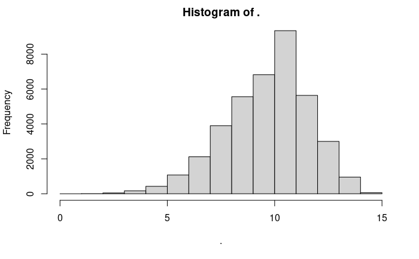

```r
gse2658_exprs_all_uams %>% select(-sample_id) %>% as.matrix() %>% hist()
```

score using values from above (log2 only)

```r
## UAMS
# select up regulated genes in data
anno_up <- gse2658_exprs_all_uams %>%
  dplyr::select(intersect(up_probe,colnames(gse2658_exprs_all_uams)))
# select down regulated genes in data
anno_dw <- gse2658_exprs_all_uams %>%
  dplyr::select(intersect(down_probe,colnames(gse2658_exprs_all_uams)))
## expression already in log2 scale
# compute means
uams_results <- gse2658_exprs_all_uams %>% dplyr::select(sample_id)
# colnames(uams_results) <- "sample_id"
uams_results$up <- anno_up %>% rowMeans()
uams_results$dw <- anno_dw %>% rowMeans()
# compute proportion of mean up/down
uams_results$ua_score <- uams_results$up - uams_results$dw # expression already in log2 scale
## Find threshold by k-means clustering
# k-means cluster analysis
fit <- kmeans(uams_results$ua_score, 3)
# get cluster max
c.uams_all <- aggregate(uams_results$ua_score,by=list(fit$cluster),FUN=max)
# append cluster assignment
uams_results$fit_cluster <- fit$cluster
# classify
uams_results$ua_group = if_else(uams_results$ua_score > median(c.uams_all$x),"high","low")

# combine results
uams_results_probe_sdata <-
  left_join(uams_results,
            gse2658_surv_info, by="sample_id")
uams_results_probe_sdata$ua_group <-
  factor(uams_results_probe_sdata$ua_group, levels = c("low","high"))

head(uams_results,10)
```

|  | sample_id | up | dw | ua_score | fit_cluster | ua_group |
| --- | --- | --- | --- | --- | --- | --- |
| 1 | GSM102606 | 9.251163 | 10.022631 | -0.77146805 | 3 | low |
| 2 | GSM102607 | 9.920718 | 9.626172 | 0.29454613 | 1 | low |
| 3 | GSM102609 | 10.815009 | 9.240821 | 1.57418824 | 2 | high |
| 4 | GSM102610 | 9.741625 | 9.674232 | 0.06739318 | 1 | low |
| 5 | GSM102611 | 9.780742 | 9.596879 | 0.18386296 | 1 | low |
| 6 | GSM102612 | 9.167644 | 9.702920 | -0.53527593 | 3 | low |
| 7 | GSM102613 | 9.978828 | 9.644779 | 0.33404874 | 1 | low |
| 8 | GSM102614 | 10.015191 | 9.377734 | 0.63745638 | 1 | low |
| 9 | GSM102615 | 10.646721 | 9.328795 | 1.31792530 | 2 | high |
| 10 | GSM102616 | 9.322995 | 9.508774 | -0.18577947 | 1 | low |

### UAMS using genes

Nicki wants me to do this by genes since that’s the way anyone would have to do it with RNAseq data

remember one of their probes maps to no gene, so full signature is 69 genes rather than 70 reported in paper

```r
length(up)
```

```
[1] 51
```

```r
exp_cbat_wnames %>% filter(gene_name %in% up) %>% distinct(gene_name) %>% dim()
```

```
[1] 37  1
```

14 missing from up

```r
up_mis <- setdiff(up, unique(exp_cbat_wnames$gene_name))
up_mis
```

```
 [1] "FABP5"   "TRIP13"  "AURKA"   "KIF14"   "BIRC5"   "SLC19A1" "WEE1"    "ROBO1"   "DSG2"    "ASPM"
[11] "FAM72B"  "CENPW"   "ZNF829"  "CHRM3"
```

```r
gse2658_features %>%
  filter(`Gene Symbol` %in% up_mis) %>%
  distinct(`Gene Symbol`) %>% pull(`Gene Symbol`)
```

```
 [1] "DSG2"    "CHRM3"   "BIRC5"   "FABP5"   "TRIP13"  "AURKA"   "KIF14"   "SLC19A1" "WEE1"    "ROBO1"
[11] "ASPM"    "CENPW"   "ZNF829"
```

13 are easy to get by name, leaves 1 to get the hard way: `FAM72B` which I had to sort out previously.  
this one is part of a gene family and the probe picks up more than one family member, but I need to label it `FAM72B` for it to line up with the RNAseq genes

```r
gse2658_features %>%
  filter(grepl("FAM72", `Gene Symbol`)) %>%
  select(ID, `Gene Symbol`:`RefSeq Transcript ID`, GB_ACC, `Representative Public ID`)
```

|  | ID | Gene Symbol | ENTREZ_GENE_ID | RefSeq Transcript ID | GB_ACC | Representative Public ID |
| --- | --- | --- | --- | --- | --- | --- |
| 225834_at | 225834_at | FAM72A /// FAM72B /// FAM72C /// FAM72D | 554282 /// 653820 /// 728833 /// 729533 | NM_001100910 /// NM_001123168 /// NM_001287385 /// NM_207418 /// XM_006710841 /// XM_006711526 | AL135396 | AL135396 |

```r
up_easy <- gse2658_features %>%
  filter(`Gene Symbol` %in% up_mis) %>%
  select(ID, gene_name=`Gene Symbol`) %>%
  left_join(., gencode_annot_gni, by="gene_name")
up_easy
```

| ID | gene_name | gene_id |
| --- | --- | --- |
| 1553105_s_at | DSG2 | ENSG00000046604 |
| 1553705_a_at | CHRM3 | ENSG00000133019 |
| 1559633_a_at | CHRM3 | ENSG00000133019 |
| 1559634_at | CHRM3 | ENSG00000133019 |
| 1564339_a_at | CHRM3 | ENSG00000133019 |
| 202094_at | BIRC5 | ENSG00000089685 |
| 202095_s_at | BIRC5 | ENSG00000089685 |
| 202345_s_at | FABP5 | ENSG00000164687 |
| 204033_at | TRIP13 | ENSG00000071539 |
| 204092_s_at | AURKA | ENSG00000087586 |

[output cut: 19 more lines]

need to add `FAM72B`

```r
gencode_annot_gni %>% filter(gene_name=="FAM72B")
```

| gene_id | gene_name |
| --- | --- |
| ENSG00000188610 | FAM72B |
| ENSG00000264820 | FAM72B |

`ENSG00000264820` no longer exists, was merged into `ENSG00000188610`

```r
up_2add <- bind_rows(up_easy,
                     data.frame(ID="225834_at", gene_name="FAM72B", gene_id="ENSG00000188610"))
up_2add
```

| ID | gene_name | gene_id |
| --- | --- | --- |
| 1553105_s_at | DSG2 | ENSG00000046604 |
| 1553705_a_at | CHRM3 | ENSG00000133019 |
| 1559633_a_at | CHRM3 | ENSG00000133019 |
| 1559634_at | CHRM3 | ENSG00000133019 |
| 1564339_a_at | CHRM3 | ENSG00000133019 |
| 202094_at | BIRC5 | ENSG00000089685 |
| 202095_s_at | BIRC5 | ENSG00000089685 |
| 202345_s_at | FABP5 | ENSG00000164687 |
| 204033_at | TRIP13 | ENSG00000071539 |
| 204092_s_at | AURKA | ENSG00000087586 |

[output cut: 20 more lines]

```r
length(down)
```

```
[1] 18
```

```r
exp_cbat_wnames %>% filter(gene_name %in% down) %>% distinct(gene_name) %>% dim()
```

```
[1] 15  1
```

only 3 missing from down

```r
down_mis <- setdiff(down, unique(exp_cbat_wnames$gene_name))
down_mis
```

```
[1] "ARHGAP29"      "LINC01016"     "RP5-1085F17.3"
```

```r
gse2658_features %>%
    filter(`Gene Symbol` %in% down_mis) %>%
    distinct(`Gene Symbol`) %>% pull(`Gene Symbol`)
```

```
[1] "ARHGAP29"      "LINC01016"     "RP5-1085F17.3"
```

can get all 3 easily

```r
down_2add <- gse2658_features %>%
  filter(`Gene Symbol` %in% down_mis) %>%
  select(ID, gene_name=`Gene Symbol`) %>%
  left_join(., gencode_annot_gni, by="gene_name")
down_2add
```

| ID | gene_name | gene_id |
| --- | --- | --- |
| 1554736_at | ARHGAP29 | ENSG00000137962 |
| 1556675_s_at | LINC01016 | ENSG00000249346 |
| 1557276_at | LINC01016 | ENSG00000249346 |
| 1557277_a_at | LINC01016 | ENSG00000249346 |
| 1558280_s_at | ARHGAP29 | ENSG00000137962 |
| 1560318_at | ARHGAP29 | ENSG00000137962 |
| 203910_at | ARHGAP29 | ENSG00000137962 |
| 227547_at | RP5-1085F17.3 | ENSG00000260257 |
| 234267_at | LINC01016 | ENSG00000249346 |
| 239729_at | RP5-1085F17.3 | ENSG00000260257 |

normalize these 2 sets then add to genes already normalized `gse2658_exprs` has the expression by probe

```r
uams_2add <- bind_rows(up_2add, down_2add)
```

17 genes, 40 probe sets

still need to finish normalizing few that are missing and putting back together with data already normed

gets expression by probe

```r
uams_g2a_gse2658_exprs <- gse2658_exprs %>% filter(probe %in% uams_2add$ID)
uams_g2a_gse2658_exprs
```

| probe | GSM50986 | GSM50987 | GSM50988 | GSM50989 | GSM50990 | GSM50991 | GSM50992 | GSM50993 | GSM50994 | GSM50995 | GSM50996 | GSM50997 | GSM50998 | GSM50999 | GSM51000 | GSM51001 | GSM51002 | GSM51003 | GSM51004 | GSM51005 | GSM51006 | GSM51007 | GSM51008 | GSM51009 | GSM51010 | GSM51011 | GSM51012 | GSM51013 | GSM51014 | … |
| --- | --- | --- | --- | --- | --- | --- | --- | --- | --- | --- | --- | --- | --- | --- | --- | --- | --- | --- | --- | --- | --- | --- | --- | --- | --- | --- | --- | --- | --- | --- |
| 1553105_s_at | 212.6 | 145.5 | 61.9 | 578.4 | 807.6 | 175.3 | 19.0 | 45.4 | 228.0 | 82.4 | 52.8 | 644.1 | 160.4 | 435.4 | 118.0 | 1736.3 | 111.8 | 93.0 | 357.2 | 37.1 | 149.1 | 39.0 | 562.8 | 68.1 | 351.2 | 83.0 | 30.5 | 133.5 | 28.1 | … |
| 1553705_a_at | 27.9 | 15.9 | 150.3 | 235.9 | 120.0 | 202.3 | 11.8 | 32.8 | 209.9 | 26.2 | 111.0 | 145.4 | 236.9 | 216.8 | 56.5 | 231.9 | 255.9 | 42.3 | 136.1 | 36.0 | 18.7 | 97.2 | 800.1 | 66.9 | 42.3 | 237.0 | 384.3 | 34.4 | 109.7 | … |
| 1554736_at | 136.2 | 135.7 | 88.1 | 195.5 | 5.2 | 60.0 | 52.0 | 102.9 | 86.9 | 125.1 | 246.6 | 69.8 | 114.2 | 130.7 | 35.9 | 33.4 | 90.8 | 84.4 | 158.8 | 235.7 | 144.6 | 108.0 | 120.1 | 114.5 | 89.2 | 181.9 | 125.5 | 41.1 | 117.6 | … |
| 1556675_s_at | 582.2 | 331.7 | 48.1 | 469.0 | 77.9 | 419.8 | 115.5 | 160.2 | 347.7 | 289.4 | 654.2 | 130.9 | 802.8 | 714.6 | 182.9 | 220.0 | 107.1 | 172.6 | 283.5 | 390.1 | 367.0 | 639.5 | 431.2 | 858.9 | 231.8 | 236.0 | 371.8 | 102.7 | 375.8 | … |
| 1557276_at | 1097.2 | 558.9 | 820.7 | 1526.5 | 464.3 | 1538.4 | 2631.0 | 1474.3 | 1169.8 | 969.4 | 1600.3 | 867.6 | 1986.5 | 2219.7 | 575.9 | 809.5 | 1271.3 | 156.5 | 525.4 | 855.1 | 1735.6 | 836.7 | 1200.8 | 870.3 | 1210.3 | 651.8 | 1558.3 | 1289.2 | 1789.7 | … |
| 1557277_a_at | 118.9 | 116.2 | 73.2 | 172.7 | 40.3 | 129.1 | 82.4 | 51.7 | 79.4 | 96.1 | 112.2 | 7.6 | 109.4 | 8.2 | 31.5 | 26.3 | 44.1 | 46.2 | 135.4 | 8.8 | 6.1 | 64.3 | 56.5 | 133.9 | 79.5 | 76.8 | 16.8 | 177.6 | 11.5 | … |
| 1558280_s_at | 108.2 | 13.7 | 11.5 | 115.2 | 35.2 | 107.8 | 7.4 | 12.3 | 27.9 | 13.7 | 101.0 | 68.1 | 53.6 | 25.8 | 15.6 | 84.5 | 7.1 | 7.9 | 24.6 | 63.8 | 60.0 | 42.9 | 20.7 | 44.8 | 94.6 | 9.0 | 57.4 | 117.9 | 26.3 | … |
| 1559633_a_at | 46.8 | 4.9 | 3.5 | 66.2 | 2.5 | 38.5 | 34.0 | 9.4 | 41.3 | 24.1 | 8.0 | 9.4 | 278.3 | 65.6 | 6.8 | 37.8 | 183.2 | 30.5 | 3.6 | 71.9 | 33.3 | 4.1 | 237.2 | 45.9 | 65.4 | 9.7 | 22.3 | 8.0 | 13.4 | … |
| 1559634_at | 12.7 | 43.5 | 44.1 | 7.1 | 5.1 | 127.9 | 7.9 | 11.6 | 111.3 | 55.4 | 98.9 | 22.3 | 156.3 | 33.7 | 57.7 | 16.0 | 58.4 | 12.4 | 130.3 | 106.9 | 26.5 | 92.0 | 46.9 | 56.6 | 85.9 | 95.6 | 123.4 | 158.1 | 28.6 | … |
| 1560318_at | 17.9 | 34.7 | 63.0 | 15.4 | 12.8 | 82.6 | 54.0 | 14.2 | 18.2 | 92.7 | 148.6 | 6.8 | 11.2 | 14.5 | 11.3 | 13.5 | 2.8 | 38.3 | 18.7 | 10.6 | 9.7 | 39.8 | 18.5 | 7.9 | 8.1 | 5.4 | 5.7 | 78.8 | 12.9 | … |

[output cut: 30 more lines]

brings in gene names and IDs

```r
uams_g2a_gse2658_exprs <-
  left_join(uams_g2a_gse2658_exprs, uams_2add, by=c("probe"="ID")) %>%
  relocate(gene_name, gene_id, .after=probe)
uams_g2a_gse2658_exprs
```

| probe | gene_name | gene_id | GSM50986 | GSM50987 | GSM50988 | GSM50989 | GSM50990 | GSM50991 | GSM50992 | GSM50993 | GSM50994 | GSM50995 | GSM50996 | GSM50997 | GSM50998 | GSM50999 | GSM51000 | GSM51001 | GSM51002 | GSM51003 | GSM51004 | GSM51005 | GSM51006 | GSM51007 | GSM51008 | GSM51009 | GSM51010 | GSM51011 | GSM51012 | … |
| --- | --- | --- | --- | --- | --- | --- | --- | --- | --- | --- | --- | --- | --- | --- | --- | --- | --- | --- | --- | --- | --- | --- | --- | --- | --- | --- | --- | --- | --- | --- |
| 1553105_s_at | DSG2 | ENSG00000046604 | 212.6 | 145.5 | 61.9 | 578.4 | 807.6 | 175.3 | 19.0 | 45.4 | 228.0 | 82.4 | 52.8 | 644.1 | 160.4 | 435.4 | 118.0 | 1736.3 | 111.8 | 93.0 | 357.2 | 37.1 | 149.1 | 39.0 | 562.8 | 68.1 | 351.2 | 83.0 | 30.5 | … |
| 1553705_a_at | CHRM3 | ENSG00000133019 | 27.9 | 15.9 | 150.3 | 235.9 | 120.0 | 202.3 | 11.8 | 32.8 | 209.9 | 26.2 | 111.0 | 145.4 | 236.9 | 216.8 | 56.5 | 231.9 | 255.9 | 42.3 | 136.1 | 36.0 | 18.7 | 97.2 | 800.1 | 66.9 | 42.3 | 237.0 | 384.3 | … |
| 1554736_at | ARHGAP29 | ENSG00000137962 | 136.2 | 135.7 | 88.1 | 195.5 | 5.2 | 60.0 | 52.0 | 102.9 | 86.9 | 125.1 | 246.6 | 69.8 | 114.2 | 130.7 | 35.9 | 33.4 | 90.8 | 84.4 | 158.8 | 235.7 | 144.6 | 108.0 | 120.1 | 114.5 | 89.2 | 181.9 | 125.5 | … |
| 1556675_s_at | LINC01016 | ENSG00000249346 | 582.2 | 331.7 | 48.1 | 469.0 | 77.9 | 419.8 | 115.5 | 160.2 | 347.7 | 289.4 | 654.2 | 130.9 | 802.8 | 714.6 | 182.9 | 220.0 | 107.1 | 172.6 | 283.5 | 390.1 | 367.0 | 639.5 | 431.2 | 858.9 | 231.8 | 236.0 | 371.8 | … |
| 1557276_at | LINC01016 | ENSG00000249346 | 1097.2 | 558.9 | 820.7 | 1526.5 | 464.3 | 1538.4 | 2631.0 | 1474.3 | 1169.8 | 969.4 | 1600.3 | 867.6 | 1986.5 | 2219.7 | 575.9 | 809.5 | 1271.3 | 156.5 | 525.4 | 855.1 | 1735.6 | 836.7 | 1200.8 | 870.3 | 1210.3 | 651.8 | 1558.3 | … |
| 1557277_a_at | LINC01016 | ENSG00000249346 | 118.9 | 116.2 | 73.2 | 172.7 | 40.3 | 129.1 | 82.4 | 51.7 | 79.4 | 96.1 | 112.2 | 7.6 | 109.4 | 8.2 | 31.5 | 26.3 | 44.1 | 46.2 | 135.4 | 8.8 | 6.1 | 64.3 | 56.5 | 133.9 | 79.5 | 76.8 | 16.8 | … |
| 1558280_s_at | ARHGAP29 | ENSG00000137962 | 108.2 | 13.7 | 11.5 | 115.2 | 35.2 | 107.8 | 7.4 | 12.3 | 27.9 | 13.7 | 101.0 | 68.1 | 53.6 | 25.8 | 15.6 | 84.5 | 7.1 | 7.9 | 24.6 | 63.8 | 60.0 | 42.9 | 20.7 | 44.8 | 94.6 | 9.0 | 57.4 | … |
| 1559633_a_at | CHRM3 | ENSG00000133019 | 46.8 | 4.9 | 3.5 | 66.2 | 2.5 | 38.5 | 34.0 | 9.4 | 41.3 | 24.1 | 8.0 | 9.4 | 278.3 | 65.6 | 6.8 | 37.8 | 183.2 | 30.5 | 3.6 | 71.9 | 33.3 | 4.1 | 237.2 | 45.9 | 65.4 | 9.7 | 22.3 | … |
| 1559634_at | CHRM3 | ENSG00000133019 | 12.7 | 43.5 | 44.1 | 7.1 | 5.1 | 127.9 | 7.9 | 11.6 | 111.3 | 55.4 | 98.9 | 22.3 | 156.3 | 33.7 | 57.7 | 16.0 | 58.4 | 12.4 | 130.3 | 106.9 | 26.5 | 92.0 | 46.9 | 56.6 | 85.9 | 95.6 | 123.4 | … |
| 1560318_at | ARHGAP29 | ENSG00000137962 | 17.9 | 34.7 | 63.0 | 15.4 | 12.8 | 82.6 | 54.0 | 14.2 | 18.2 | 92.7 | 148.6 | 6.8 | 11.2 | 14.5 | 11.3 | 13.5 | 2.8 | 38.3 | 18.7 | 10.6 | 9.7 | 39.8 | 18.5 | 7.9 | 8.1 | 5.4 | 5.7 | … |

[output cut: 30 more lines]

pivot to long data

```r
uams_g2a_gse2658_exprs_long <- uams_g2a_gse2658_exprs %>%
  pivot_longer(-c(gene_name, gene_id, probe), names_to = "sample_id", values_to = "expr")
head(uams_g2a_gse2658_exprs_long, 10)
```

| probe | gene_name | gene_id | sample_id | expr |
| --- | --- | --- | --- | --- |
| 1553105_s_at | DSG2 | ENSG00000046604 | GSM50986 | 212.6 |
| 1553105_s_at | DSG2 | ENSG00000046604 | GSM50987 | 145.5 |
| 1553105_s_at | DSG2 | ENSG00000046604 | GSM50988 | 61.9 |
| 1553105_s_at | DSG2 | ENSG00000046604 | GSM50989 | 578.4 |
| 1553105_s_at | DSG2 | ENSG00000046604 | GSM50990 | 807.6 |
| 1553105_s_at | DSG2 | ENSG00000046604 | GSM50991 | 175.3 |
| 1553105_s_at | DSG2 | ENSG00000046604 | GSM50992 | 19.0 |
| 1553105_s_at | DSG2 | ENSG00000046604 | GSM50993 | 45.4 |
| 1553105_s_at | DSG2 | ENSG00000046604 | GSM50994 | 228.0 |
| 1553105_s_at | DSG2 | ENSG00000046604 | GSM50995 | 82.4 |

sum up multiple probe sets by gene

```r
uams_g2a_gse2658_exprs_long_sum <- uams_g2a_gse2658_exprs_long %>%
  group_by(gene_name, gene_id, sample_id) %>%
  summarise(gene_expr=sum(expr))
head(uams_g2a_gse2658_exprs_long_sum, 10)
```

| gene_name | gene_id | sample_id | gene_expr |
| --- | --- | --- | --- |
| ARHGAP29 | ENSG00000137962 | GSM102606 | 183.6 |
| ARHGAP29 | ENSG00000137962 | GSM102607 | 98.5 |
| ARHGAP29 | ENSG00000137962 | GSM102609 | 147.9 |
| ARHGAP29 | ENSG00000137962 | GSM102610 | 341.3 |
| ARHGAP29 | ENSG00000137962 | GSM102611 | 226.8 |
| ARHGAP29 | ENSG00000137962 | GSM102612 | 166.3 |
| ARHGAP29 | ENSG00000137962 | GSM102613 | 155.3 |
| ARHGAP29 | ENSG00000137962 | GSM102614 | 105.2 |
| ARHGAP29 | ENSG00000137962 | GSM102615 | 180.5 |
| ARHGAP29 | ENSG00000137962 | GSM102616 | 160.9 |

join on gene length

```r
uams_g2a_gse2658_exprs_long_sum_wgl <-
  left_join(uams_g2a_gse2658_exprs_long_sum, gencode_gene_len, by="gene_id")
head(uams_g2a_gse2658_exprs_long_sum_wgl, 10)
```

| gene_name | gene_id | sample_id | gene_expr | length |
| --- | --- | --- | --- | --- |
| ARHGAP29 | ENSG00000137962 | GSM102606 | 183.6 | 21856 |
| ARHGAP29 | ENSG00000137962 | GSM102607 | 98.5 | 21856 |
| ARHGAP29 | ENSG00000137962 | GSM102609 | 147.9 | 21856 |
| ARHGAP29 | ENSG00000137962 | GSM102610 | 341.3 | 21856 |
| ARHGAP29 | ENSG00000137962 | GSM102611 | 226.8 | 21856 |
| ARHGAP29 | ENSG00000137962 | GSM102612 | 166.3 | 21856 |
| ARHGAP29 | ENSG00000137962 | GSM102613 | 155.3 | 21856 |
| ARHGAP29 | ENSG00000137962 | GSM102614 | 105.2 | 21856 |
| ARHGAP29 | ENSG00000137962 | GSM102615 | 180.5 | 21856 |
| ARHGAP29 | ENSG00000137962 | GSM102616 | 160.9 | 21856 |

calculate cpk

```r
uams_g2a_gse2658_exprs_long_sum_wgl <-
  uams_g2a_gse2658_exprs_long_sum_wgl %>% mutate(cpk=gene_expr/length)
head(uams_g2a_gse2658_exprs_long_sum_wgl,10)
```

| gene_name | gene_id | sample_id | gene_expr | length | cpk |
| --- | --- | --- | --- | --- | --- |
| ARHGAP29 | ENSG00000137962 | GSM102606 | 183.6 | 21856 | 0.008400439 |
| ARHGAP29 | ENSG00000137962 | GSM102607 | 98.5 | 21856 | 0.004506772 |
| ARHGAP29 | ENSG00000137962 | GSM102609 | 147.9 | 21856 | 0.006767021 |
| ARHGAP29 | ENSG00000137962 | GSM102610 | 341.3 | 21856 | 0.015615849 |
| ARHGAP29 | ENSG00000137962 | GSM102611 | 226.8 | 21856 | 0.010377013 |
| ARHGAP29 | ENSG00000137962 | GSM102612 | 166.3 | 21856 | 0.007608895 |
| ARHGAP29 | ENSG00000137962 | GSM102613 | 155.3 | 21856 | 0.007105600 |
| ARHGAP29 | ENSG00000137962 | GSM102614 | 105.2 | 21856 | 0.004813324 |
| ARHGAP29 | ENSG00000137962 | GSM102615 | 180.5 | 21856 | 0.008258602 |
| ARHGAP29 | ENSG00000137962 | GSM102616 | 160.9 | 21856 | 0.007361823 |

join on size factor

```r
uams_g2a_gse2658_exprs_long_sum_wgl_sz <-
  left_join(uams_g2a_gse2658_exprs_long_sum_wgl, gse2658_sample_size_factors, by="sample_id")
```

calculate adjusted normalized expression (`adjlogcpkmed`)

```r
uams_gse2658_exprs_adj <- uams_g2a_gse2658_exprs_long_sum_wgl_sz %>%
  mutate(adjlogcpkmed=log2(cpk/szfctr))
```

```r
uams_gse2658_exprs_adj
```

| gene_name | gene_id | sample_id | gene_expr | length | cpk | szfctr | adjlogcpkmed |
| --- | --- | --- | --- | --- | --- | --- | --- |
| ARHGAP29 | ENSG00000137962 | GSM102606 | 183.6 | 21856 | 0.008400439 | 0.12988675 | -3.95064568 |
| ARHGAP29 | ENSG00000137962 | GSM102607 | 98.5 | 21856 | 0.004506772 | 0.12953498 | -4.84510362 |
| ARHGAP29 | ENSG00000137962 | GSM102609 | 147.9 | 21856 | 0.006767021 | 0.12822038 | -4.24396095 |
| ARHGAP29 | ENSG00000137962 | GSM102610 | 341.3 | 21856 | 0.015615849 | 0.12961564 | -3.05315692 |
| ARHGAP29 | ENSG00000137962 | GSM102611 | 226.8 | 21856 | 0.010377013 | 0.13127203 | -3.66109640 |
| ARHGAP29 | ENSG00000137962 | GSM102612 | 166.3 | 21856 | 0.007608895 | 0.12737312 | -4.06523015 |
| ARHGAP29 | ENSG00000137962 | GSM102613 | 155.3 | 21856 | 0.007105600 | 0.13159842 | -4.21104186 |
| ARHGAP29 | ENSG00000137962 | GSM102614 | 105.2 | 21856 | 0.004813324 | 0.12682228 | -4.71963104 |
| ARHGAP29 | ENSG00000137962 | GSM102615 | 180.5 | 21856 | 0.008258602 | 0.13797976 | -4.06241537 |
| ARHGAP29 | ENSG00000137962 | GSM102616 | 160.9 | 21856 | 0.007361823 | 0.12969200 | -4.13888258 |

[output cut: 990 more lines]

this is just the 17 genes missing from `exp_cbat_wnames`

rest are here:  
but this also has survival cols

```r
uams_gse2658_adj_easy <- exp_cbat_wnames %>% filter(gene_name %in% c(up, down)) %>%
  relocate(gene_name)
head(uams_gse2658_adj_easy,10)
```

| gene_name | gene_id | sample_id | adjlogcpkmed | censos | ttcos |
| --- | --- | --- | --- | --- | --- |
| LAS1L | ENSG00000001497 | GSM102606 | -1.12778532 | 0 | 1.37 |
| LAS1L | ENSG00000001497 | GSM102607 | -0.51859373 | 0 | 9.03 |
| LAS1L | ENSG00000001497 | GSM102609 | -0.41825355 | 0 | 7.23 |
| LAS1L | ENSG00000001497 | GSM102610 | -0.66219388 | 0 | 6.93 |
| LAS1L | ENSG00000001497 | GSM102611 | -0.67981233 | 0 | 6.97 |
| LAS1L | ENSG00000001497 | GSM102612 | -0.83575225 | 0 | 6.93 |
| LAS1L | ENSG00000001497 | GSM102613 | -0.43643948 | 0 | 6.60 |
| LAS1L | ENSG00000001497 | GSM102614 | -0.78016969 | 0 | 6.37 |
| LAS1L | ENSG00000001497 | GSM102615 | 0.07517773 | 0 | 6.30 |
| LAS1L | ENSG00000001497 | GSM102616 | -0.78534696 | 0 | 6.30 |

put it all together with survival info

```r
uams_gse2658_exprs_adj <- left_join(uams_gse2658_exprs_adj, gse2658_surv_info, by="sample_id") %>%
  select(gene_name, gene_id, sample_id, adjlogcpkmed, censos, ttcos)
uams_gse2658_adj_all <- bind_rows(uams_gse2658_adj_easy, uams_gse2658_exprs_adj)
uams_gse2658_adj_all
```

| gene_name | gene_id | sample_id | adjlogcpkmed | censos | ttcos |
| --- | --- | --- | --- | --- | --- |
| LAS1L | ENSG00000001497 | GSM102606 | -1.1277853247 | 0 | 1.37 |
| LAS1L | ENSG00000001497 | GSM102607 | -0.5185937341 | 0 | 9.03 |
| LAS1L | ENSG00000001497 | GSM102609 | -0.4182535510 | 0 | 7.23 |
| LAS1L | ENSG00000001497 | GSM102610 | -0.6621938771 | 0 | 6.93 |
| LAS1L | ENSG00000001497 | GSM102611 | -0.6798123335 | 0 | 6.97 |
| LAS1L | ENSG00000001497 | GSM102612 | -0.8357522499 | 0 | 6.93 |
| LAS1L | ENSG00000001497 | GSM102613 | -0.4364394779 | 0 | 6.60 |
| LAS1L | ENSG00000001497 | GSM102614 | -0.7801696873 | 0 | 6.37 |
| LAS1L | ENSG00000001497 | GSM102615 | 0.0751777287 | 0 | 6.30 |
| LAS1L | ENSG00000001497 | GSM102616 | -0.7853469631 | 0 | 6.30 |

[output cut: 990 more lines]

```r
uams_gse2658_adj_all %>% distinct(gene_name) %>% dim()
```

```
[1] 69  1
```

correct number of genes

#### risk groups by UAMS genes

score using genes (log2 and normalized)

```r
## use gene names. genes are columns, individuals are rows
uams_gse2658_adj_all_wide <- uams_gse2658_adj_all %>%
  select(-gene_id) %>%
  pivot_wider(names_from="gene_name", values_from="adjlogcpkmed")
### calculating once on all data
## UAMS
# select up regulated genes in data
anno_up <- uams_gse2658_adj_all_wide %>%
  dplyr::select(intersect(up,colnames(uams_gse2658_adj_all_wide)))
# select down regulated genes in data
anno_dw <- uams_gse2658_adj_all_wide %>%
  dplyr::select(intersect(down,colnames(uams_gse2658_adj_all_wide)))
## expression already in log2 scale
# compute means
uams_results_gene <- uams_gse2658_adj_all_wide %>% dplyr::select(sample_id)
# colnames(uams_results_gene) <- "sample_id"
uams_results_gene$up <- anno_up %>% rowMeans()
uams_results_gene$dw <- anno_dw %>% rowMeans()
# compute proportion of mean up/down
uams_results_gene$ua_score <- uams_results_gene$up - uams_results_gene$dw # expression already in log2 scale
## Find threshold by k-means clustering
# k-means cluster analysis
fit <- kmeans(uams_results_gene$ua_score, 3)
# get cluster max
c.uams_all <- aggregate(uams_results_gene$ua_score,by=list(fit$cluster),FUN=max)
# append cluster assignment
uams_results_gene$fit_cluster <- fit$cluster
# classify
uams_results_gene$ua_group = if_else(uams_results_gene$ua_score > median(c.uams_all$x),"high","low")

# combine results
uams_results_gene_sdata <-
  left_join(uams_results_gene,
            gse2658_surv_info, by="sample_id")
uams_results_gene_sdata$ua_group <- factor(uams_results_gene_sdata$ua_group, levels = c("low","high"))


head(uams_results_gene,10)
```

| sample_id | up | dw | ua_score | fit_cluster | ua_group |
| --- | --- | --- | --- | --- | --- |
| GSM102606 | -0.2611426489 | 0.8772205 | -1.1383632 | 2 | low |
| GSM102607 | 0.3071951051 | 0.7543542 | -0.4471591 | 3 | low |
| GSM102609 | 1.1079608352 | 0.3329675 | 0.7749933 | 1 | high |
| GSM102610 | -0.0008872989 | 0.6884833 | -0.6893706 | 3 | low |
| GSM102611 | 0.1161135676 | 0.7265679 | -0.6104543 | 3 | low |
| GSM102612 | -0.3478754059 | 0.9170351 | -1.2649105 | 2 | low |
| GSM102613 | 0.2503394872 | 0.6854974 | -0.4351579 | 3 | low |
| GSM102614 | 0.3425814846 | 0.6053221 | -0.2627406 | 3 | low |
| GSM102615 | 0.7436358144 | 0.3758138 | 0.3678220 | 1 | high |
| GSM102616 | -0.2059795041 | 0.5855626 | -0.7915421 | 3 | low |

### UAMS and SBUK hazards ratios

actuarial and CoxPH for all three

actuarial hazard function

```r
act.haz.se <- function(data, time, event, class){
  data <- as.data.frame(data)
  time <- data[,time]
  event <- data[,event]
  class <- data[,class]
  temp_sdf <- survdiff(Surv(time, event) ~ class)
  HR <- (temp_sdf$obs[2]/temp_sdf$exp[2])/(temp_sdf$obs[1]/temp_sdf$exp[1])
  SE <- sqrt(1/temp_sdf$exp[1] + 1/temp_sdf$exp[2])
  CIL <- exp(log(HR)-(1.96*SE))
  CIU <- exp(log(HR)+(1.96*SE))
  return(c(hr=HR,se.ln.hr=SE,conf.low=CIL,conf.up=CIU))
}
```

#### UAMS probe

```r
## actuarial HR
uams_probe_act_hr <- act.haz.se(uams_results_probe_sdata, "ttcos", "censos", "ua_group")
uams_probe_act_hr
```

```
        hr   se.ln.hr   conf.low    conf.up
 5.4576200  0.3562105  2.7151308 10.9702322
```

```r
## CoxPH HR
summary(uams_probe_cph_sum <- coxph(Surv(ttcos, censos) ~ ua_group,
              data=dplyr::select(uams_results_probe_sdata, ttcos, censos, ua_group)))
```

```
Call:
coxph(formula = Surv(ttcos, censos) ~ ua_group, data = dplyr::select(uams_results_probe_sdata,
    ttcos, censos, ua_group))

  n= 559, number of events= 100

               coef exp(coef) se(coef)     z Pr(>|z|)
ua_grouphigh 1.7729    5.8881   0.2197 8.071 6.99e-16 ***
---
Signif. codes:  0 ‘***’ 0.001 ‘**’ 0.01 ‘*’ 0.05 ‘.’ 0.1 ‘ ’ 1

             exp(coef) exp(-coef) lower .95 upper .95
ua_grouphigh     5.888     0.1698     3.828     9.057

Concordance= 0.637  (se = 0.025 )
Likelihood ratio test= 52.13  on 1 df,   p=5e-13
Wald test            = 65.14  on 1 df,   p=7e-16
Score (logrank) test = 83.28  on 1 df,   p=<2e-16
```

#### UAMS genes

```r
## actuarial HR
uams_gene_act_hr <- act.haz.se(uams_results_gene_sdata, "ttcos", "censos", "ua_group")
uams_gene_act_hr
```

```
       hr  se.ln.hr  conf.low   conf.up
3.6144286 0.3078093 1.9770930 6.6077285
```

```r
## CoxPH HR
summary(uams_gene_cph_sum <- coxph(Surv(ttcos, censos) ~ ua_group,
              data=dplyr::select(uams_results_gene_sdata, ttcos, censos, ua_group)))
```

```
Call:
coxph(formula = Surv(ttcos, censos) ~ ua_group, data = dplyr::select(uams_results_gene_sdata,
    ttcos, censos, ua_group))

  n= 559, number of events= 100

               coef exp(coef) se(coef)     z Pr(>|z|)
ua_grouphigh 1.3318    3.7877   0.2189 6.083 1.18e-09 ***
---
Signif. codes:  0 ‘***’ 0.001 ‘**’ 0.01 ‘*’ 0.05 ‘.’ 0.1 ‘ ’ 1

             exp(coef) exp(-coef) lower .95 upper .95
ua_grouphigh     3.788      0.264     2.466     5.817

Concordance= 0.612  (se = 0.025 )
Likelihood ratio test= 31.18  on 1 df,   p=2e-08
Wald test            = 37  on 1 df,   p=1e-09
Score (logrank) test = 42.63  on 1 df,   p=7e-11
```

#### SBUK

```r
## actuarial HR
sbuk_act_hr <- act.haz.se(sbuk_results_sdata, "ttcos", "censos", "sb_group")
sbuk_act_hr
```

```
       hr  se.ln.hr  conf.low   conf.up
2.7768500 0.2468901 1.7115725 4.5051531
```

```r
## CoxPH HR
summary(sbuk_cph_sum <- coxph(Surv(ttcos, censos) ~ sb_group,
              data=dplyr::select(sbuk_results_sdata, ttcos, censos, sb_group)))
```

```
Call:
coxph(formula = Surv(ttcos, censos) ~ sb_group, data = dplyr::select(sbuk_results_sdata,
    ttcos, censos, sb_group))

  n= 559, number of events= 100

               coef exp(coef) se(coef)    z Pr(>|z|)
sb_grouphigh 1.0439    2.8403   0.2055 5.08 3.77e-07 ***
---
Signif. codes:  0 ‘***’ 0.001 ‘**’ 0.01 ‘*’ 0.05 ‘.’ 0.1 ‘ ’ 1

             exp(coef) exp(-coef) lower .95 upper .95
sb_grouphigh      2.84     0.3521     1.899     4.249

Concordance= 0.614  (se = 0.027 )
Likelihood ratio test= 23.66  on 1 df,   p=1e-06
Wald test            = 25.81  on 1 df,   p=4e-07
Score (logrank) test = 28.13  on 1 df,   p=1e-07
```